# Module 2: Horizontal Integration (Meta-Analysis)

ISMB 2026 Tutorial VT4: Multimodal Integration and Multimodal Causal Inference using R/Bioconductor

Saptarshi Roy, Sreya Sarkar, Himel Mallick

July 06, 2026

# 1 Introduction

Meta-analysis, a form of horizontal integration, is a statistical analysis that combines the results of multiple scientific studies by appropriately weighting the individual study-specific effect sizes. A common meta-analytic combination strategy is to take a weighted average of the study-specific summary measures. In fixed-effects meta-analysis, the weights are based on the assumption that there is a single true parameter underlying all the studies, while in random-effects meta-analysis, the weights are based on a model where the true parameter varies across studies according to a probability distribution.

Meta-analysis is particularly useful when individual studies are small, and a joint analysis of these studies can enhance the precision of effect size estimation and improve statistical power. Especially in microbiome studies, individual effect sizes from each study tend to be small. Only through meta-analysis can these small effects reach statistical significance. Therefore, by jointly analyzing these studies, we amplify the collective voice of the data, offering a more comprehensive understanding of the effects under investigation.

In this module, we demonstrate the implementation of horizontal integration by utilizing publicly available cancer microbiome datasets from the R/Bioconductor package `curatedMetagenomicData`. Our demonstration comprises two components as follows:

- [`MMUPHin`](https://www.bioconductor.org/packages/release/bioc/html/MMUPHin.html)(Meta-Analysis Methods with a Uniform Pipeline for Heterogeneity in microbiome studies) - [A Unimodal Framework]
- [`muffinette`](https://github.com/himelmallick/muffinette)(Meta-Analysis of Differential Microbiome Networks) - [A Unimodal Framework]

# 2 Setup

Install the following R packages to get started.

```r
knitr::opts_chunk$set(echo = TRUE)

## Global Packages for data availability and/or visualization/demonstration
library(curatedMetagenomicData) ## source: Bioconductor
library(cowplot) ## source: CRAN
library(ggplot2) ## source: CRAN
library(ggpubr) ## source: CRAN
library(dplyr) ## source: CRAN
library(tidyverse) ## source: CRAN
library(parallel) ## Base R package

## For MMUPHin
library(vegan) ## source: CRAN
library(MMUPHin) ## source: Bioconductor
library(huge)


## For Network visualization
library(SpiecEasi) ## source: Github, devtools::install_github("zdk123/SpiecEasi")
library(SPRING) ## source: Github, devtools::install_github("GraceYoon/SPRING")
# library(igraph) ## source: CRAN
library(NetCoMi)
## source: Github
# devtools::install_github("stefpeschel/NetCoMi",
#                          repos = c("https://cloud.r-project.org/",
#                                    BiocManager::repositories()))

## For muffinette
library(muffinette) # source: Github, devtools::install_github("himelmallick/muffinette")
```

# 3 Meta-Analysis with `MMUPHin`

In this section, we provide detailed examples of how to perform batch effect correction and meta-analytic differential abundance testing on publicly available cancer microbiome data from multiple studies using the R package `MMUPHin`. `MMUPHin` is a R/Bioconductor package designed for meta-analysis of microbiome taxonomic and functional profiles. It is agnostic to the data type and leverages another R/Bioconductor package, `MaAsLin3`, as a backend to conduct the meta-analysis. `MaAsLin3` is particularly designed to be applicable to various microbial community data types (taxonomy or functional profiles) and environments (human or otherwise). It is modular, including implementations of alternative normalization/transformation schemes and statistical models (e.g., for amplicon vs. shotgun metagenomic profiles). Leveraging this flexible framework under the hood, `MMUPHin` performs normalization, batch effect correction, and meta-analysis using the default random effects meta-regression.

# 4 Data Pre-processing

We use the relative abundance data from 5 public datasets under the `curatedMetagenomicData` package. In this analysis, we will use two input files. The first input file is the relative abundance data file, which consists of **a feature-by-sample matrix**. The second input is **the metadata** associated with the relative abundance file, which includes the study names and combines overall response rate (ORR), progression-free survival at 12 months (PFS12), as well as the response to anti-PD-1 (anti_PD_1) as the response variable.

```r
######################
# Load melanoma data #
######################

se_relative <- sampleMetadata |>
  filter(study_name %in% c("FrankelAE_2017", "GopalakrishnanV_2018", "LeeKA_2022",
                         "MatsonV_2018", "PetersBA_2019", "WindTT_2020")) |>
  returnSamples("relative_abundance", rownames = "short")
```

```r
##########################
# Create sample metadata #
##########################

data_meta <- dplyr::select(as.data.frame(colData(se_relative)),
                    c("study_name", "ORR", "PFS12", "anti_PD_1"))

# Define response variable
data_meta$resvar <- NA
data_meta$anti_PD_1[data_meta$anti_PD_1 == "responder"] <- "yes"
data_meta$anti_PD_1[data_meta$anti_PD_1 == "non_responder"] <- "no"
data_meta$resvar[!is.na(data_meta$anti_PD_1)] <- data_meta$anti_PD_1[!is.na(data_meta$anti_PD_1)]
data_meta$resvar[!is.na(data_meta$PFS12)] <- data_meta$PFS12[!is.na(data_meta$PFS12)]
data_meta$resvar[!is.na(data_meta$ORR)] <- data_meta$ORR[!is.na(data_meta$ORR)]


cat(sprintf("Before filtering samples: Total %d samples from %d studies.\n\n",
            nrow(data_meta), length(unique(data_meta$study_name))))
```

```
#> Before filtering samples: Total 315 samples from 6 studies.
```

```r
# Filter individuals without response variable
data_meta <- data_meta[!is.na(data_meta$resvar), c("study_name", "resvar")]
cat(sprintf("After filtering samples: Total %d samples from %d studies.\n\n",
            nrow(data_meta), length(unique(data_meta$study_name))))
```

```
#> After filtering samples: Total 285 samples from 5 studies.
```

```r
# Convert the "study_name" to factor variable
data_meta$study_name <- as.factor(data_meta$study_name)


###########################
# Create Species Features #
###########################
# Transpose the abundance matrix and change the value of abundance
# data to proportion unit
data_abd <- assay(se_relative)
data_abd <- data_abd / 100

# Match the individuals in the data_abd
data_abd <- data_abd[, colnames(data_abd) %in% rownames(data_meta)]

# Change the rownames names for variables of interest
rownames(data_abd) <- sub('.*s__', '', rownames(data_abd))
```

To reduce noise and remove uninformative features, we filtered the data using predefined **abundance** and **prevalence** thresholds. Abundance filtering removes consistently negligible features, while prevalence filtering excludes features present in only a small fraction of samples.

In our analysis, we set the abundance threshold to 0, meaning no features were removed based on magnitude, and applied a prevalence threshold of 0.1, retaining features observed in at least 10% of samples. This reduces instability from extremely rare features while improving interpretability and computational efficiency. For this purpose, we use the `filter_abdfeatures()` function from the R package `muffinette`.

Next, we apply an additional step of filtering to remove features exhibiting little variability across samples. To achieve this, we utilize the `filter_varfeatures()` function from the R package `muffinette`. This function first eliminates the features with near-zero variance, and sorts the remaining features in decreasing order of variance. For computational efficiency, this function further allows the user to retain only the top $K$ most variable features.

```r
###############################
# Study-wise feature filtering #
###############################

# Make sure abundance matrix columns are exactly the filtered samples
# and in the same order as data_meta
data_abd <- data_abd[, rownames(data_meta), drop = FALSE]

# Optional sanity check
stopifnot(all(colnames(data_abd) == rownames(data_meta)))

# Split sample IDs by study
samples_by_study <- split(rownames(data_meta), data_meta$study_name)

# Apply filtering study-wise
data_abd_filtered_list <- lapply(names(samples_by_study), function(study) {

  samp_ids <- samples_by_study[[study]]

  # Feature-by-sample matrix for one study
  abd_study <- data_abd[, samp_ids, drop = FALSE]

  cat(sprintf(
    "\nStudy: %s | Before filtering: %d samples on %d features.\n",
    study, ncol(abd_study), nrow(abd_study)
  ))

  # filter_abdfeatures expects sample-by-feature matrix
  abd_study_filtered <- filter_abdfeatures(
    x = t(abd_study),
    abd_threshold = 0,
    prev_threshold = 0.1)

  # filter variable features within the same study
  abd_study_filtered <- filter_varfeatures(
    x = abd_study_filtered,
    topV = NULL)

  # Transpose back to feature-by-sample matrix
  abd_study_filtered <- as.matrix(t(abd_study_filtered))

  cat(sprintf(
    "Study: %s | After filtering: %d samples on %d features.\n",
    study, ncol(abd_study_filtered), nrow(abd_study_filtered)
  ))

  return(abd_study_filtered)
})
```

```
#>
#> Study: FrankelAE_2017 | Before filtering: 39 samples on 671 features.
#> Study: FrankelAE_2017 | After filtering: 39 samples on 276 features.
#>
#> Study: LeeKA_2022 | Before filtering: 165 samples on 671 features.
#> Study: LeeKA_2022 | After filtering: 165 samples on 227 features.
#>
#> Study: MatsonV_2018 | Before filtering: 38 samples on 671 features.
#> Study: MatsonV_2018 | After filtering: 38 samples on 214 features.
#>
#> Study: PetersBA_2019 | Before filtering: 23 samples on 671 features.
#> Study: PetersBA_2019 | After filtering: 23 samples on 193 features.
#>
#> Study: WindTT_2020 | Before filtering: 20 samples on 671 features.
#> Study: WindTT_2020 | After filtering: 20 samples on 176 features.
```

```r
names(data_abd_filtered_list) <- names(samples_by_study)

## Pooled feature-by-sample matrix
common_features <- Reduce(intersect, lapply(data_abd_filtered_list, rownames))

data_abd_filtered_common_list <- lapply(data_abd_filtered_list, function(x) {
  x[common_features, , drop = FALSE]
})
data_abd_filtered_common <- do.call(cbind, data_abd_filtered_common_list)

dim(data_abd_filtered_common)
```

```
#> [1] 121 285
```

```r
data_abd_filtered_common <- data_abd_filtered_common[, rownames(data_meta),
                                                     drop = FALSE]

stopifnot(all(colnames(data_abd_filtered_common) == rownames(data_meta)))
```

At the end of these steps, we have prepared the two required input files consisting of **285 samples of relative abundances on 121 features collected from 5 different studies**.

# 5 Batch Effect Adjustment with `adjust_batch`

Here, we will perform the batch effect correction analysis using the `adjust_batch` function from `MMUPHin`, adjusting for the response variable `resvar`. A brief description of the function arguments is as follows:

- `feature_abd`: feature-by-sample matrix of abundances (proportions/counts)
- `batch`: name of the batch variable (should be a factor variable included in the metadata)
- `covariates`: names of covariates to adjust for in the batch-correction model
- `data`: data frame of metadata, columns must include exposure and batch and covariates to adjust for (if specified)

```r
# Use adjust_batch to correct for differences in the five studies, while
# controlling for the effect of cases versus control (variable resvar in data_meta).
fit_adjust_batch <- MMUPHin::adjust_batch(feature_abd = data_abd_filtered_common,
                                 batch = "study_name",
                                 covariates = "resvar",
                                 data = data_meta,
                                 control = list(verbose = FALSE))

data_abd_adj <- fit_adjust_batch$feature_abd_adj
```

By the end of this step, we obtain a feature-by-sample (121 $\times$ 285) batch-adjusted relative abundance matrix.

# 6 Evaluation of Batch Effect Adjustment

After obtaining the adjusted abundance matrix, we can evaluate the improvement of the batch effect adjustment. Here, the total variation from study difference will be assessed through the PERMANOVA$^14$ test, using the R package `vegan`.

```r
D_before <- vegan::vegdist(t(data_abd_filtered_common))
D_after <- vegan::vegdist(t(data_abd_adj))

set.seed(1)
fit_adonis_before <- vegan::adonis2(D_before ~ study_name, data = data_meta)
fit_adonis_after <- vegan::adonis2(D_after ~ study_name, data = data_meta)

print(fit_adonis_before)
```

```
#> Permutation test for adonis under reduced model
#> Permutation: free
#> Number of permutations: 999
#>
#> vegan::adonis2(formula = D_before ~ study_name, data = data_meta)
#>           Df SumOfSqs      R2    F Pr(>F)
#> Model      4   11.489 0.13151 10.6  0.001 ***
#> Residual 280   75.871 0.86849
#> Total    284   87.360 1.00000
#> ---
#> Signif. codes:  0 '***' 0.001 '**' 0.01 '*' 0.05 '.' 0.1 ' ' 1
```

```r
print(fit_adonis_after)
```

```
#> Permutation test for adonis under reduced model
#> Permutation: free
#> Number of permutations: 999
#>
#> vegan::adonis2(formula = D_after ~ study_name, data = data_meta)
#>           Df SumOfSqs      R2      F Pr(>F)
#> Model      4    2.820 0.03361 2.4343  0.001 ***
#> Residual 280   81.093 0.96639
#> Total    284   83.913 1.00000
#> ---
#> Signif. codes:  0 '***' 0.001 '**' 0.01 '*' 0.05 '.' 0.1 ' ' 1
```

Based on the results, we can see that the study differences can explain a total of 13.2% ($R^2$) of the variability in microbial abundance profiles before study effect adjustment, whereas after adjustment this was reduced to 3.4% ($R^2$).

Let us now visualize the results of the PERMANOVA test.

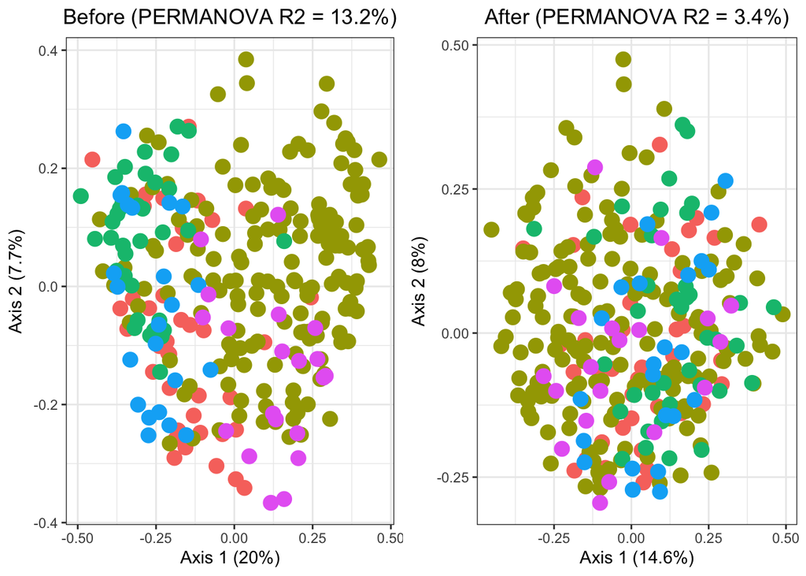

```r
##############
# Ordination #
##############
# Before
R2_before <- round(fit_adonis_before$R2[1]*100, 1)
pcoa_before <- cmdscale(D_before, eig = TRUE)
ord_before <- as.data.frame(pcoa_before$points)
percent_var_before <- round(pcoa_before$eig / sum(pcoa_before$eig) * 100, 1)[1:2]
before_labels <- c(paste('Axis 1 (', percent_var_before[1], '%)', sep = ''),
                 paste('Axis 2 (', percent_var_before[2], '%)', sep = ''))

before_phrase <- paste('Before (PERMANOVA R2 = ', R2_before, '%)', sep = '')
colnames(ord_before) <- c('PC1', 'PC2')
ord_before$Study <- data_meta$study_name

# After
R2_after <- round(fit_adonis_after$R2[1]*100, 1)
pcoa_after <- cmdscale(D_after, eig = TRUE)
ord_after <- as.data.frame(pcoa_after$points)
percent_var_after <- round(pcoa_after$eig / sum(pcoa_after$eig) * 100, 1)[1:2]
after_labels <- c(paste('Axis 1 (', percent_var_after[1], '%)', sep = ''),
                paste('Axis 2 (', percent_var_after[2], '%)', sep = ''))

after_phrase <- paste('After (PERMANOVA R2 = ', R2_after, '%)', sep = '')
colnames(ord_after) <- c('PC1', 'PC2')
ord_after$Study <- data_meta$study_name

# Ordination Plot
p_before <- ggplot(ord_before, aes(x = PC1, y = PC2, color = Study)) +
  geom_point(size = 4) +
  theme_bw() +
  xlab(before_labels[1]) +
  ylab(before_labels[2]) +
  ggtitle(before_phrase) +
  theme(plot.title = element_text(hjust = 0.5)) +
  theme(legend.position ="none")

p_after <- ggplot(ord_after, aes(x = PC1, y = PC2, color = Study)) +
  geom_point(size = 4) +
  theme_bw() +
  xlab(after_labels[1]) +
  ylab(after_labels[2]) +
  ggtitle(after_phrase) +
  theme(plot.title = element_text(hjust = 0.5)) +
  theme(legend.position ="none")

p <- plot_grid(p_before, p_after, ncol = 2)
p
```

# 7 Differential Abundance Testing with `maaslin_meta`

Here, we illustrate the details of the meta-analytical differential abundance testing through the `maaslin_meta` function provided by the `MMUPHin` packages with the following specifications:

- `feature_abd`: feature-by-sample matrix of abundances (proportions/counts)
- `batch`: name of the batch variable (should be a factor variable included in the metadata)
- `exposure`: name of the exposure variable for differential abundance testing
- `covariates`: names of covariates to adjust for in `MaAslin3` differential abundance testing models.
- `covariates_random`: names of random-effects grouping covariates to adjust for in `MaAslin3` differential abundance testing models.
- `data`: data frame of metadata, columns must include exposure and batch and covariates to adjust for (if specified)
- `control`: a named list of additional parameters including normalization technique, transformation to use and analysis method. See `MaAsLin3` for details. Moreover, several choices of estimation method are available for fitting either a fixed-effects or a random-effects model for meta-analysis. Refer to `rma.uni()` in the R package `metafor`.

Here, we apply the Tweedie model using the “CPLM” analysis method in `MaAsLin3` and pass it as part of control.

```r
fit_maaslin_meta <- MMUPHin::maaslin_meta(feature_abd = data_abd_adj,
                batch = "study_name",
                exposure = "resvar",
                data = data_meta,
                control = list(analysis_method = 'CPLM', transform = 'LOG'))

meta_mmuph_abd <- fit_maaslin_meta$meta_fits_abundance
meta_mmuph_prev <- fit_maaslin_meta$meta_fits_prevalence

sig_species_meta_abd <- meta_mmuph_abd[meta_mmuph_abd$qval.fdr < 0.05, 1]
sig_species_meta_prev <- meta_mmuph_prev[meta_mmuph_prev$qval.fdr < 0.05, 1]
sig_species_meta_abd
```

```
#> character(0)
```

```r
sig_species_meta_prev
```

```
#> character(0)
```

This step yields a data frame of per-feature meta-analytical differential abundance results, including columns for effect sizes, p-values and q-values, heterogeneity statistics such as $\tau^2$ and $I^2$, as well as weights for individual batches. More details of these statistics are included in `rma.uni()` in `metafor` package.

Based on the results from `MMUPHin`, we observe that there are NO significant species.

# 8 Meta-Network Analysis with `muffinette`

Microbial communities operate through complex ecological interactions that are better understood via network-based analyses. Many existing work in the literature (eg. SparCC, SpiecEasi etc.) construct microbial association networks within individual studies in order to capture interspecies relationships. `muffinette` is a novel statistical framework designed to meta-analyze such networks across studies to identify reproducible interaction patterns.

After the pre-processing steps similar to those used in `MMUPHin`, including prevalence and variance-based filtering, and followed by adjustment of batch (study) effects, `muffinette` introduces the following additional steps of network-level connectivity modeling procedures, executed per study, prior to conducting meta-analysis across studies.

1. Estimation of within-study correlation networks
2. Calculation of feature-level connectivity scores
3. Calculation of feature-by-sample pseudovalue matrix

Here, we demonstrate these steps for one study.

# 9 Per-Study Abundance Preparation

```r
batch_levels <- levels(as.factor(data_meta$study_name))
exp_levels <- levels(as.factor(data_meta$resvar))

## vector of sample sizes for different studies
ni <- as.numeric(table(factor(data_meta$study_name, levels = batch_levels)))
ni_ends <- cumsum(ni)
ni_starts <- c(1, ni_ends[-length(ni)] + 1)

## Consider the first study for demonstration
## Extract the corresponding batch-corrected abundance matrix
study1 <- batch_levels[1]
data_abd_adj_all <- t(data_abd_adj)
study1_abd <- data_abd_adj_all[ni_starts[1]:ni_ends[1], ]

## extracting indices of two groups of response (No and Yes)
grpA <- which(data_meta$resvar[data_meta$study_name == study1] == exp_levels[1])
grpB <- which(data_meta$resvar[data_meta$study_name == study1] == exp_levels[2])


## extracting the group-specific abundances
xA <- study1_abd[grpA, , drop = FALSE]
xB <- study1_abd[grpB, , drop = FALSE]


## Remove the study from analysis if sample size is limited
if(nrow(xA) < 5 | nrow(xB) < 5) {
    message(sprintf("Skipping study %s: too few samples per
    exposure (nA = %d, nB = %d)", studies[i], nrow(xA), nrow(xB)))
    estimatedNet <- NULL
    pseudoVal <- NULL
}
```

# 10 Network Estimation

```r
fixseed <- 1
ncores <- 4

## Setting seed for reproducibility across parallel network estimations
cl <- parallel::makeCluster(ncores)
# on.exit(parallel::stopCluster(cl), add = TRUE)
if(!is.null(fixseed)) {
# ensure master uses reproducible parallel RNG
RNGkind("L'Ecuyer-CMRG")
set.seed(fixseed)

# ensure workers use same RNG engine
parallel::clusterEvalQ(cl, {
    RNGkind("L'Ecuyer-CMRG")
    NULL
})

# generate independent streams for workers
parallel::clusterSetRNGStream(cl, iseed = fixseed)
}

parallel::clusterExport(cl, varlist = c("networkEst"),
                envir = environment())


## Estimation of feature-by-feature association matrix
estimatedNet_groupA <- networkEst(x = xA,
                                  estimethod = "SparCC",
                                  iter = 20, inner_iter = 10, th = 0.1)
estimatedNet_groupB <- networkEst(x = xB,
                                  estimethod = "SparCC",
                                  iter = 20, inner_iter = 10, th = 0.1)
estimatedNet <- list(estimatedNet_groupA = estimatedNet_groupA,
                     estimatedNet_groupB = estimatedNet_groupB)


## global network-connectivity measurement
thetahat_groupA <- measureNetwork(estimatedNet_groupA)
thetahat_groupB <- measureNetwork(estimatedNet_groupB)


## Estimation of feature-by-feature association matrix
## leaving one-subject-out
## using parLapply for computational efficiency
clusterExport(cl, varlist = c("xA"),
                        envir = environment())

estimatedNet_loo_groupA <- parLapply(cl, X = seq_len(nrow(xA)),
            fun = function(j) {
                tryCatch(networkEst(x = xA[-j, , drop = FALSE],
                        estimethod = "SparCC",
                        iter = 20, inner_iter = 10, th = 0.1),
                            error = function(e) e)})
clusterExport(cl, varlist = c("xB"),
                        envir = environment())

estimatedNet_loo_groupB <- parLapply(cl, X = seq_len(nrow(xB)),
            fun = function(j) {
                tryCatch(networkEst(x = xB[-j, , drop = FALSE],
                        estimethod = "SparCC",
                        iter = 20, inner_iter = 10, th = 0.1),
                            error = function(e) e)})

## global network-connectivity measurement leaving one-subject-out
thetahat_loo_groupA <- sapply(estimatedNet_loo_groupA, measureNetwork)
thetahat_loo_groupB <- sapply(estimatedNet_loo_groupB, measureNetwork)

parallel::stopCluster(cl)
rm(cl)
```

# 11 Network Visualization

Let us visualize these two networks from the two groups using the `NetCoMi` package.

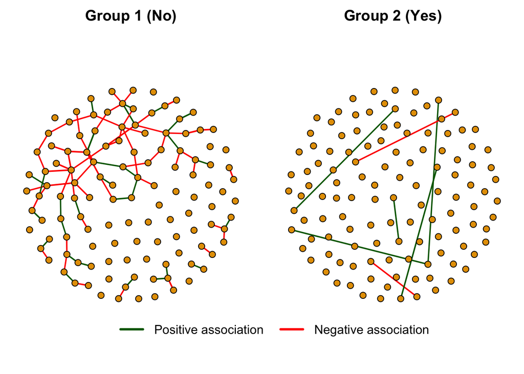

```r
net <- NetCoMi::netConstruct(data = as.matrix(estimatedNet_groupA),
                    data2 = as.matrix(estimatedNet_groupB),
                    dataType  = "correlation",
                    sparsMethod = "threshold",
                    dissFunc = "unsigned",
                    thresh = 0.19,
                    weighted  = TRUE,
                    verbose = 0)

A1 <- net$assoMat1
A2 <- net$assoMat2

g1 <- igraph::graph_from_adjacency_matrix(A1, mode="undirected",
                                          weighted=TRUE, diag=FALSE)
g2 <- igraph::graph_from_adjacency_matrix(A2, mode="undirected",
                                          weighted=TRUE, diag=FALSE)

# Layout graph with positive weights (abs), but keep original g1/g2 for plotting
g1_layout <- g1
igraph::E(g1_layout)$weight <- abs(igraph::E(g1_layout)$weight)

L <- igraph::layout_with_fr(g1_layout)

# edge aesthetics using ORIGINAL sign
igraph::E(g1)$color <- ifelse(igraph::E(g1)$weight > 0, "darkgreen", "red")
igraph::E(g2)$color <- ifelse(igraph::E(g2)$weight > 0, "darkgreen", "red")
igraph::E(g1)$width <- 1 + 4*abs(igraph::E(g1)$weight)
igraph::E(g2)$width <- 1 + 4*abs(igraph::E(g2)$weight)


par(mfrow=c(1,2), mar=c(1,1,2,1))
plot(g1, layout=L, vertex.size=6, vertex.label=NA, main="Group 1 (No)")
plot(g2, layout=L, vertex.size=6, vertex.label=NA, main="Group 2 (Yes)")

# move to outer margin space
par(xpd=NA)

legend(x = -2.72, y = -1.15,
       legend = c("Positive association", "Negative association"),
       col = c("darkgreen", "red"),
       lwd = 3,
       horiz = TRUE,
       inset = -0.001,
       bty = "n",
       cex = 1)
```

```r
par(mfrow=c(1,1), xpd=FALSE)
```

# 12 Jackknife Pseudovalues

We now calculate the jackknife pseudovalues for the $i$-th subject and $k$-th feature as

$$\tilde{\theta}_{ik} = n\hat{\theta}_k -
(n-1)\hat{\theta}_{k(-i)}$$
.

We use the `pseudoValue` function from the `muffinette` package to do this task. The function takes the following arguments:

- `thetahatinput` network measure of all subjects,
- `thetahatdropinput` network measure leaving-one-subject-out,
- `sizegroup` number of observations,

and returns a sample-by-feature matrix of jackknife pseudovalues.

```r
## Calculation of jackknife pseudovalues
pseudoVal_groupA <- pseudoValue(thetahat_groupA, thetahat_loo_groupA,
                                nrow(xA))
pseudoVal_groupB <- pseudoValue(thetahat_groupB, thetahat_loo_groupB,
                                nrow(xB))
pseudoVal <- matrix(NA, nrow(study1_abd), ncol(study1_abd))
pseudoVal[grpA, ] <- pseudoVal_groupA
pseudoVal[grpB, ] <- pseudoVal_groupB
pseudoVal <- scale(pseudoVal, center = TRUE, scale = TRUE)

## Maps the column names (feature names)
colnames(pseudoVal) <- colnames(study1_abd)

cat(sprintf("A sample-by-feature (%d x %d) matrix of
jackknife pseudovalues for study %s:\n\n", nrow(pseudoVal),
ncol(pseudoVal), study1))
```

```
#> A sample-by-feature (39 x 121) matrix of
#> jackknife pseudovalues for study FrankelAE_2017:
```

```r
print(pseudoVal[1:4, 1:3])
```

```
#>      species:Ruminococcus bromii species:Bacteroides uniformis
#> [1,]                  -0.4212755                    -0.6763265
#> [2,]                  -0.0259515                    -0.3609401
#> [3,]                  -0.4084904                    -0.2784273
#> [4,]                  -0.6169414                     1.0123419
#>      species:Phocaeicola vulgatus
#> [1,]                   -1.5123792
#> [2,]                    0.1865674
#> [3,]                   -0.2527876
#> [4,]                   -1.7056490
```

# 13 Differential Network Meta-Analysis

We repeat the aforesaid steps for every study and construct a sample-by-feature (285$\times$ 121) pseudovalue matrix. Finally, we perform meta-network-analysis of these pseudovalues across studies to discover consistent network-based signatures. The `muffinette` function in the R package `muffinette` implements this entire workflow as demonstrated below.

```r
###########################################
# Study-wise abundance list without filter #
###########################################

# Make sure abundance matrix columns are exactly the filtered samples
# and in the same order as data_meta
data_abd <- data_abd[, rownames(data_meta), drop = FALSE]

# Sanity check
stopifnot(all(colnames(data_abd) == rownames(data_meta)))

fit_muffinette <- muffinette(metaAbd = data_abd,
                             batchvar = data_meta$study_name,
                             exposurevar = data_meta$resvar,
                             metaData = data_meta,
                             prevfilter = TRUE, filter_perstudy = TRUE,
                             abd_threshold = 0, prev_threshold = 0.1,
                             topfeatures = NULL,
                             comp = TRUE, net.est.method = "SparCC",
                             covariates = NULL, covariates_random = NULL,
                             ncores = 4, verbose = TRUE,
                             fixseed = 2310, control = NULL)
```

```
#> Network estimated for study 1 / 5
#> Network estimated for study 2 / 5
#> Network estimated for study 3 / 5
#> Network estimated for study 4 / 5
#> Network estimated for study 5 / 5
#> Meta-analysis done...
```

```r
meta_muffinette <- fit_muffinette$metafits

## Inspect the meta-analysis table.
## NOTE: use head()/kable() rather than View() -- View() opens the interactive
## RStudio data viewer and cannot run inside a knit (it requires X11/XQuartz
## and errors with "X11 library is missing").
knitr::kable(head(meta_muffinette, 10))
```

|  | feature | exposure | coef | stderr | pval | k | tau2 | stderr.tau2 | pval.tau2 | I2 | H2 | weight_FrankelAE_2017 | weight_LeeKA_2022 | weight_MatsonV_2018 | weight_PetersBA_2019 | weight_WindTT_2020 | qval |
| --- | --- | --- | --- | --- | --- | --- | --- | --- | --- | --- | --- | --- | --- | --- | --- | --- | --- |
| species:Blautia obeum | species:Blautia obeum | yes | -0.7593014 | 0.1116308 | 0.0000000 | 5 | 0.0000000 | 0.0486869 | 0.9274846 | 0.00000 | 1.000000 | 13.98813 | 57.26183 | 12.67487 | 8.159844 | 7.915326 | 0.0000000 |
| species:Roseburia inulinivorans | species:Roseburia inulinivorans | yes | 0.9377439 | 0.2470552 | 0.0001472 | 5 | 0.2259533 | 0.2152668 | 0.0009811 | 77.88969 | 4.522777 | 20.33257 | 25.11429 | 20.42118 | 17.961504 | 16.170467 | 0.0029693 |
| species:Parabacteroides merdae | species:Parabacteroides merdae | yes | -1.0703248 | 0.2761070 | 0.0001060 | 5 | 0.3048830 | 0.2689945 | 0.0000253 | 83.26559 | 5.975711 | 19.67205 | 23.33872 | 21.21473 | 19.797533 | 15.976959 | 0.0029693 |
| species:Bacteroides xylanisolvens | species:Bacteroides xylanisolvens | yes | 1.0442883 | 0.2732230 | 0.0001323 | 5 | 0.3011924 | 0.2635126 | 0.0000148 | 84.64064 | 6.510688 | 20.77299 | 23.76559 | 20.30569 | 18.106614 | 17.049118 | 0.0029693 |
| species:Oscillibacter sp. 57_20 | species:Oscillibacter sp. 57_20 | yes | 1.1043966 | 0.2835216 | 0.0000981 | 5 | 0.3257135 | 0.2836692 | 0.0000039 | 84.27554 | 6.359518 | 20.99429 | 23.12446 | 20.53720 | 19.253024 | 16.091028 | 0.0029693 |
| species:Eubacterium ramulus | species:Eubacterium ramulus | yes | 0.9578257 | 0.2479207 | 0.0001118 | 5 | 0.2291282 | 0.2167185 | 0.0002862 | 78.95784 | 4.752363 | 20.52705 | 25.18624 | 20.80706 | 17.112473 | 16.367172 | 0.0029693 |
| species:[Eubacterium] siraeum | species:[Eubacterium] siraeum | yes | 0.5246402 | 0.1640446 | 0.0013831 | 5 | 0.0486827 | 0.0949491 | 0.1379532 | 36.80680 | 1.582449 | 18.26765 | 37.48865 | 18.30125 | 13.555818 | 12.386639 | 0.0185950 |
| species:Sellimonas intestinalis | species:Sellimonas intestinalis | yes | -1.0567149 | 0.3295555 | 0.0013437 | 5 | 0.4800680 | 0.3838468 | 0.0000035 | 90.37890 | 10.393820 | 20.66576 | 21.87027 | 19.36368 | 19.070203 | 19.030094 | 0.0185950 |
| species:Intestinimonas butyriciproducens | species:Intestinimonas butyriciproducens | yes | 0.9569871 | 0.2961168 | 0.0012302 | 5 | 0.3548871 | 0.3094020 | 0.0000004 | 85.52731 | 6.909565 | 22.49788 | 23.26490 | 19.37786 | 18.232450 | 16.626905 | 0.0185950 |
| species:Adlercreutzia equolifaciens_1 | species:Adlercreutzia equolifaciens_1 | yes | 1.0077658 | 0.3266127 | 0.0020321 | 5 | 0.4566180 | 0.3769095 | 0.0000000 | 87.90499 | 8.267871 | 19.45627 | 22.23152 | 20.99782 | 19.324885 | 17.989504 | 0.0245879 |

```r
sig_species_muffinette <- meta_muffinette[meta_muffinette$qval < 0.05, 1]
sig_species_muffinette
```

```
#>  [1] "species:Blautia obeum"
#>  [2] "species:Roseburia inulinivorans"
#>  [3] "species:Parabacteroides merdae"
#>  [4] "species:Bacteroides xylanisolvens"
#>  [5] "species:Oscillibacter sp. 57_20"
#>  [6] "species:Eubacterium ramulus"
#>  [7] "species:[Eubacterium] siraeum"
#>  [8] "species:Sellimonas intestinalis"
#>  [9] "species:Intestinimonas butyriciproducens"
#> [10] "species:Adlercreutzia equolifaciens_1"
#> [11] "species:Anaerobutyricum hallii"
```

Let us now evaluate the results obtained by `muffinette`.

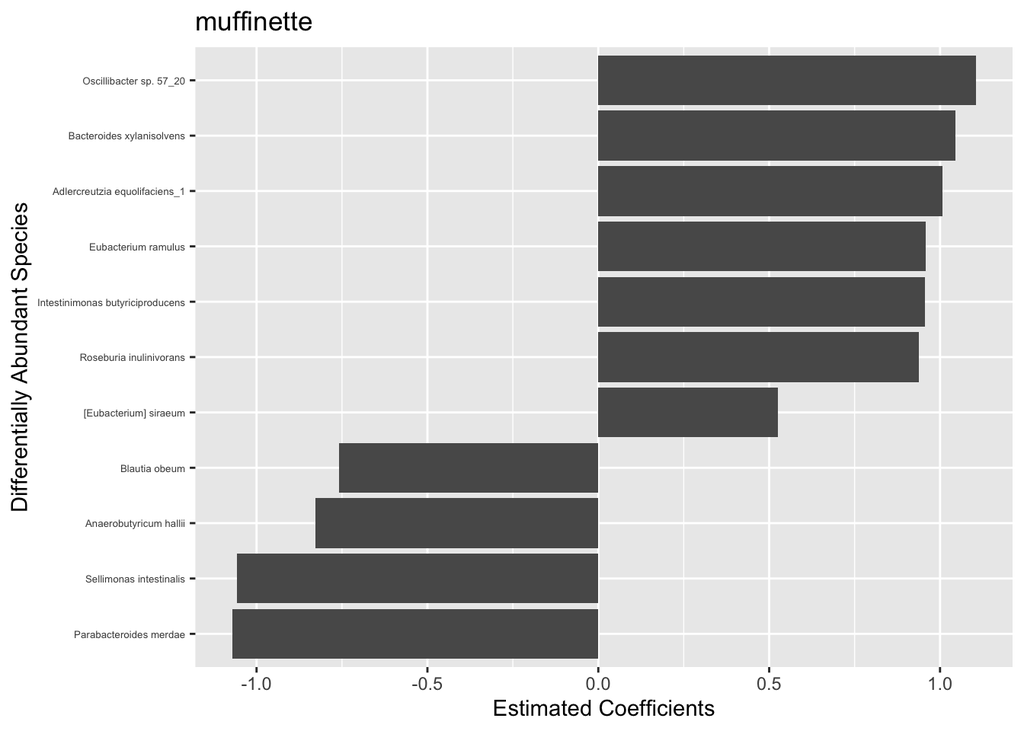

```r
fig_muffinette <- meta_muffinette %>%
  filter(qval < 0.05) %>%
  mutate(feature = sub("^species:", "", feature)) %>%
  ggplot(aes(y = coef, x = reorder(feature, coef))) +
  geom_bar(stat = "identity") +
  coord_flip() +
  theme(axis.text.y = element_text(size = 5)) +
  labs(y = "Estimated Coefficients",
       x = "Differentially Abundant Species", title = "muffinette")



fig_muffinette
```